# INF8111 - Fouille de données

## TP1 Automne 2019 - Preprocessing de tweets pour de l'analyse de sentiments

##### Membres de l'équipe:

```
- Boisvenue, Étienne (1798942)
- Le Page, Pierre-Étienne (1689985)
- Wong, Jade (1738089)
```

## Présentation

Twitter est un réseau social permettant aux utilisateurs de publier des informations et communiquer entre eux par le biais de messages, appelés tweets, pouvant contenir jusqu'à 280 caractères. Largement utilisé aujourd'hui, ce réseau peut être un outil pour des entreprises qui souhaitent évaluer l'avis de leurs clients.

Dans ce TP, on se met à la place d'une compagnie aérienne, qui souhaiterait détecter les tweets qui la mentionnent et analyser si ce sont des mentions positives ou négatives, en comparant leur résultat avec les autres compagnies.

Le *preprocessing* est une tâche cruciale en fouille de données. Elle permet de transformer les données brutes en un format adapté à l'application de méthodes de machine learning.

# I/ Analyse de sentiments (13 Pts)

Usuellement dans la littérature, la tâche d'extraire le sentiment d'un texte est appelé *sentiment analysis*. Ici pour se faire, nous allons utiliser un modèle *bag-of-words* (BoW).

## 1. Installation

Pour ce TP, vous aurez besoin des librairies `numpy`, `sklearn` et `scipy` (que vous avez sans doute déjà), ainsi que la librairie `nltk`, qui est une libraire utilisée pour faire du traitement du language (Natural Language Processing, NLP)

Installez les libraires en question et exécutez le code ci-dessous :

```python
# If you want, you can use anaconda and install after nltk library
# !pip install --user numpy
# !pip install --user sklearn
# !pip install --user scipy
# !pip install --user nltk

import sys
import nltk
import numpy as np
import pickle
from itertools import chain
import matplotlib
from matplotlib import pyplot as plt
import nltk
nltk.download("punkt")
nltk.download("stopwords")
nltk.download("averaged_perceptron_tagger")
nltk.download("universal_tagset")
```

```
True
```

## 2. Jeu de données

On utilise un jeu de donnée provenant de *Crowdflower's Data for Everyone library*: https://www.figure-eight.com/data-for-everyone/

Pour citer la source originale de la base :

```
A sentiment analysis job about the problems of each major U.S. airline. Twitter data was scraped from February of 2015 and contributors were asked to first classify positive, negative, and neutral tweets, followed by categorizing negative reasons (such as "late flight" or "rude service").
```

Les compagnies incluses dans cette base de données sont Virgin America, United Airline, Southwest Airlines, jetBlue, USAirways, et American Airlines.

Dans le fichier zip du TP, vous trouverez le fichier *airline_tweets_database.csv*, qui est la base de données de tweets que nous allons manipuler.

Chaque ligne de ce fichier contient un tweet, avec plusieurs informations : l'identifiant du tweet, l'utilisateur, le contenu, le nombre de retweet... Ainsi que le label.

3 labels différents sont possibles dans ce dataset : *négatif*, *neutre* et *positif*, que l'on va représenter respectivement par 0, 1 et 2.

Pour ce TP, on ne va conserver ici que le texte et le label. On divise ensuite la base de données en 3 ensembles (entrainement/validation/test). Vous utiliserez l'ensemble d'entraînement et de validation pour cette partie, et l'ensemble de test à la partie suivante.

Le code ci-dessous permet de charger ces ensembles:

```python
import csv
from sklearn.model_selection import train_test_split

def load_dataset(path):

    x = []
    y = []

    with open(path, 'r', newline='', encoding="latin-1") as csvfile:

        reader = csv.reader(csvfile, delimiter=',')

        # Taking the header of the file + the index of useful columns:
        header = next(reader)
        ind_label = header.index('airline_sentiment')
        ind_text = header.index('text')

        for row in reader:
            x.append(row[ind_text])

            label = row[ind_label]

            if label == "negative":
                y.append(0)
            elif label == "neutral":
                y.append(1)
            elif label == "positive":
                y.append(2)

        assert len(x) == len(y)

        return x, y


# Path of the dataset
path = "data/airline_tweets_database.csv"

X, y = load_dataset(path)

train_valid_X, test_X, train_valid_Y, test_Y = train_test_split(X, y, test_size=0.15, random_state=12)

train_X, valid_X, train_Y, valid_Y = train_test_split(train_valid_X, train_valid_Y, test_size=0.18, random_state=12)

print("Length of training set : ", len(train_X))
print("Length of validation set : ", len(valid_X))
print("Length of test set : ", len(test_X))
```

```
Length of training set :  10204
Length of validation set :  2240
Length of test set :  2196
```

## 3. Preprocessing

Nous allons ici implémenter la *tokenization* et le *stemming*, qui sont 2 étapes courantes de preprocessing en NLP. Ensuite, afin d'avoir un modèle qui s'adapte mieux au format de Twitter, nous ajouterons une étape spécifique supplémentaire.

### 3.1. Tokenization

Cette étape permet de séparer un texte en séquence de *tokens* (= jetons, ici des mots, symboles ou ponctuation).

Par exemple la phrase *"It's the student's notebook."* peut être séparé en liste de tokens de cette manière: ["it", " 's", "the", "student", " 's", "notebook", "."].

**De plus, tous les tokenizers ont également le rôle de mettre le texte en minuscule.**

##### Question 1. Implémentez les 2 tokenizers différents suivants: (0.5 Pts)

- Le **SpaceTokenizer**, qui est un tokenizer naïf qui sépare simplement en fonction des espaces.
- Le **NLTKTokenizer**, qui utilise la méthode du package *nltk* (https://www.nltk.org/api/nltk.html).

```python
from nltk.tokenize import TweetTokenizer

class SpaceTokenizer(object):
    """
    It tokenizes the tokens that are separated by whitespace (space, tab, newline).
    We consider that any tokenization was applied in the text when we use this tokenizer.

    For example: "hello\tworld of\nNLP" is split in ['hello', 'world', 'of', 'NLP']
    """

    def tokenize(self, text):
        # TODO
        tokens=[]
        tokens=text.split(' ')

        # Have to return a list of tokens
        return tokens


class NLTKTokenizer(object):
    """
    This tokenizer uses the default function of nltk package (https://www.nltk.org/api/nltk.html) to tokenize the text.
    """

    def tokenize(self, text):
        # TODO
        tokens=[]
        tokenizer=TweetTokenizer()
        tokens=tokenizer.tokenize(text)

        # Have to return a list of tokens
        return tokens
```

#### Testez les deux tokenizers. Quelles différences pouvez-vous constater?

```python
# Sélection d'un tweet à tokenizer
to_tokenize=train_X[1]
print('Tweet original que l\'on désire transformer liste de token:')
print(to_tokenize)
print('\n')

# On test le SpaceTokenizer()
space_object=SpaceTokenizer()
space_token=space_object.tokenize(to_tokenize)
print('Résultat du SpaceTokenizer:')
print(space_token)
print('\n')


# On test le NLTKTokenizer()
NLTK_object=NLTKTokenizer()
NLTK_tokens=NLTK_object.tokenize(to_tokenize)
print('Résultat du NLTKTokenizer:')
print(NLTK_tokens)
```

```
Tweet original que l'on désire transformer liste de token:
@SouthwestAir Hi! I just saw a Black History month commercial on TV &amp; Im excited! In support of this month,will you all grant me 1 free trip


Résultat du SpaceTokenizer:
['@SouthwestAir', 'Hi!', 'I', 'just', 'saw', 'a', 'Black', 'History', 'month', 'commercial', 'on', 'TV', '&amp;', 'Im', 'excited!', 'In', 'support', 'of', 'this', 'month,will', 'you', 'all', 'grant', 'me', '1', 'free', 'trip']


Résultat du NLTKTokenizer:
['@SouthwestAir', 'Hi', '!', 'I', 'just', 'saw', 'a', 'Black', 'History', 'month', 'commercial', 'on', 'TV', '&', 'Im', 'excited', '!', 'In', 'support', 'of', 'this', 'month', ',', 'will', 'you', 'all', 'grant', 'me', '1', 'free', 'trip']
```

**Comparaison des deux tokenizers**

Nous constatons que le *TweetTokenizer()* de *nltk* génère un token pour les signes de ponctuation alors que le *tokenizer* naïf crée un token seulement lorsque qu'il voit un espace. Ainsi, lorsqu'on utilise le *tokenizer* naïf, tous les mots en fin de phrase possède un caractère *point* (.) à la fin du token.

Tous les signes de ponctuation (incluant les signes & ! ? . , ') deviennent des tokens individuels lorsque l'on utilise le *TweetTokenizer()*.

Les deux *tokenizers* retournent une liste dont chaque élément est une chaîne de caractère représentant un token.

### 3.2. Troncature (ou Stemming)

Dans les phrases "I should have bought a new shoes today" et "I spent too much money buying games", les mots "buying" et "bought" représentent la même idée. Considérer ces deux mots comme différents ne ferait qu'augmenter pour rien la complexité et la dimension du problème, ce qui peut avoir un impact négatif sur la performance globale. Ainsi, on peut donc plutôt une forme unique (comme la racine du mot) pour représenter ces deux mots de la même manière. Ce procédé de conversion de mots en racines permettant de réduire la dimension est appelé usuellement *stemming*, que l'on peut traduire par troncature.

#### Question 2. Récupérez les troncatures des tokens en utilisant l'attribut *stemmer* de la classe *Stemmer* (0.5 Pts)

```python
from nltk.stem.snowball import SnowballStemmer


class Stemmer(object):

    def __init__(self):
        self.stemmer = SnowballStemmer("english", ignore_stopwords=False)

    def stem(self, token):
        """
        tokens: a list of strings
        """
        # TODO
        token=self.stemmer.stem(token)

        # Have to return a list of stems
        return token
```

```python
# On test Stemmer.stem()
stemmer_object=Stemmer()
to_stem=['Airplane','flying', 'EaTing','Apple','Great','Beautifully','Oldest','a','the','if','.',',','therefore']
for i in range(len(to_stem)):
    print(to_stem[i])
    print(stemmer_object.stem(to_stem[i]))
```

```
Airplane
airplan
flying
fli
EaTing
eat
Apple
appl
Great
great
Beautifully
beauti
Oldest
oldest
a
a
the
the
if
if
.
.
,
,
therefore
therefor
```

**Commentaires**

Le processus de troncature, aussi appelé *stemming*, réduit les mots à leur racine étymologique et phonétique. Ainsi, le mot *flying* n'est pas réduit au verbe à l'infinitif *fly*, mais plutôt au mot *fli* qui représente le verbe *to fly* phonétiquement. Les mots tronqués grâce au processus sont tous retournés en minuscule. Cela permet d'uniformiser les éléments en sortie de *stemmer.stem()*.

D'autre part, les *stopwords* se retouvent en sortie du processus de *stemming*. En effet, malgré le nom trompeur de l'argument, lorsque ce dernier vaut *vrai*, *ignore_stopwords* du *SnowballStemmer* ne tronque pas les *stopwords* et les retourne inchangés. Ainsi, dans ce cas, puisque l'argument vaut *faux*, les *stopwords* sont retournés tronqués.

### 3.3. Twitter preprocessing

Parfois, appliquer uniquement ces deux étapes ne suffit pas, due aux particularités des données que nous manipulons, qui peuvent demander des étapes de preprocessing spécifiques afin d'obtenir un modèle plus adapté.

Couramment en NLP, un dictionnaire est utilisé pour stocker un ensemble de mots, et tous les mots n'appartenant pas au dictionnaire sont considérés comme inconnus. Ainsi, avec ce choix d'implémentation, la dimension de l'espace caractéristique du modèle est directement liée au nombre de mots du dictionnaire. Ainsi, pour des raisons de complexité mais aussi car les modèles à trop grande dimension peuvent souffrir du fléau de la dimensionnalité, il est préférable de réduire la taille de notre vocabulaire.

#### Question 3. Donnez, en expliquant brièvement, au moins deux exemples d'étapes de préprocessing qui permettent de réduire la taille du dictionnaire ici, puis implémentez-les. (2.0 points)

Ces étapes de préprocessing doivent être en rapport aux charactéristiques spécifiques des données de Twitter. La suppression des mots vides ne compte pas comme une des deux étapes.

```python
import string
import re


class TwitterPreprocessing(object):

    def preprocess(self, tweet):
        """
        tweet: original tweet
        """
        # TODO : Write your preprocessing steps here.

        # On retire les hyperliens
        tweet = re.sub(r"http\S+", "", tweet)

        # On retire les ''hashtags''
        tweet = re.sub(r"#\S+", "", tweet)

        # On retourne le tweet qui a été pre-processed
        new_tweet=tweet
        return new_tweet
```

```python
# On test la classe TwitterPreprocessing
proc_object=TwitterPreprocessing()
print(proc_object.preprocess(' Voici une  #premier #deuxieme https://www.google.com/ phrase'))
```

```
 Voici une     phrase
```

**Explications**

Nos deux étapes de *preprocessing* consistent à retirer tous les URLs et tous les *hashtags*. Pour ces deux étapes, nous utilisons du *regular expression matching*. On détecte un patron (*pattern*) de caractères et on supprime ce qui se trouve après selon certaines règles.

Pour retirer les URLs, nous détectons la chaîne de caractère 'http' et nous supprimons tout ce qui suit jusqu'au prochain espace. Similairement, pour retirer les *hashtags*, nous détectons tous les signes de dièse (*#*) et nous supprimons tout ce suit jusqu'au prochain espace.

Pour réduire la taille du vocabulaire, il est définitivement recommandé de supprimer les mots vides (*stopwords*). Ils sont vides de sens, ne nous aident pas à classifier les tweets par sentiment et reviennent dans tous les textes. Par contre, cette méthode ne compte pas parmi nos deux étapes de *preprocessing*, tel qu'indiqué dans l'énoncé de la question.

Dans un premier temps, nous avons décidé d'éliminer les URLs pour plusieurs raisons. Tout d'abord, les URLs ne représentent pas directement un sentiment et n'ajoutent pas directement de sens au tweet. Certes, l'URL pourrait rediriger vers une page qui exprime très clairement l'émotion de l'auteur du tweet, mais ce traitement dépasse **largement** le contexte de ce TP. Ils n'aident donc pas vraiment à catégoriser les tweets selon l'émotion ressentie par l'auteur. Ensuite, il est très peu probable qu'un URL se retrouve dans plusieurs tweets. Ainsi, ce *feature* est inutile, car lorsque l'on crée nos *bags of words*, il sera pratiquement toujours nul à travers les observations. Les URLs ne font tout simplement pas partie de la langue anglaise. Ce ne sont pas des mots. Intrinsèquemment, ils ne sont pas porteurs de sens sémantique. Enfin, si nous gardions tous les URLs présents dans le jeu de données d'entraînement, notre *bag of words* serait inutillement gros; en les supprimant, nous ne perdons pas de valeur et nous réduisons la taille du vocabulaire.

Dans un dernier temps, nous avons décidé d'éliminer les *hashtags*, car un peu comme les URLs, il est peu probable de retrouver un même *hashtag* dans plusieurs tweets. Oui, il est probable que certains *hashtags* génériques tels que *#angry*, *#flying*, *#trip* et *#vacation* se retrouvent dans plusieurs tweets, mais ils ne représentent qu'une petite proportion de l'utilité réelle des *hashtags*. En fait, plusieurs personnes se servent des *hashtags* pour combiner plusieurs mots, par exemple: *#IAmSoAngry*, *#IWantARefund*, *ThisAirlineIsTheWorst*, etc, donc ils sont habituellement porteurs de sens. Nous les avons tout de même éliminés, car ce sens est très difficile à extraire et il y a de fortes chances que de nombreux *hashtags* dans l'ensemble d'entraînement ne se retrouvent jamais dans les données de test (et augmentent inutilement la taille du vocabulaire). Ces *hashtags* peuvent contenir tout et n'importe quoi. En l'absence de caractère délimitant les différents mots contenus dans un *hashtag*, il devient ardu d'en extraire un sens. Puisqu'ils peuvent contenir de nombreux mots collés ensemble, il est fort probable que les *hashtags* dans notre jeu de données soient uniques. Ainsi, ce *feature* serait nul pour toutes les autres observations, ajoutant très peu de valeur à l'analyse des sentiments, mais il consommerait considérablement de ressources (temps, mémoire, stockage).

### 3.4. Pipeline

Une pipeline permet d'exécuter séquentiellement toutes les étapes de preprocessing, pour transformer les données brutes en une version utilisable pour notre modèle. La *PreprocessingPipeline* a été implémenter pour appliquer à la suite le tokenizer, les troncatures et le preprocessing spécifique à Twitter.

**N'hésitez pas à changer l'ordre des étapes de preprocessing si vous le souhaitez.**

```python
class PreprocessingPipeline:

    def __init__(self, tokenization, twitterPreprocessing, stemming):
        """
        tokenization: enable or disable tokenization.
        twitterPreprocessing: enable or disable twitter preprocessing.
        stemming: enable or disable stemming.
        """

        self.tokenizer = NLTKTokenizer() if tokenization else SpaceTokenizer()
        self.twitterPreprocesser = TwitterPreprocessing(
        ) if twitterPreprocessing else None
        self.stemmer = Stemmer() if stemming else None

    def preprocess(self, tweet):
        """
        Transform the raw data

        tokenization: boolean value.
        twitterPreprocessing: boolean value. Apply the
        stemming: boolean value.
        """

        if self.twitterPreprocesser:
            tweet = self.twitterPreprocesser.preprocess(tweet)

        tokens = self.tokenizer.tokenize(tweet)

        if self.stemmer:
            tokens = list(map(self.stemmer.stem, tokens))

        return tokens
```

Test de la pipeline :

```python
pipeline = PreprocessingPipeline(tokenization=True, twitterPreprocessing=True, stemming=True)
print('Tweet original:')
print(train_X[:1])
print('Tweet ayant passer à travers le preprocessing:')
print(list(map(pipeline.preprocess, train_X[:1])))
```

```
Tweet original:
['@USAirways tells me to talk to @AmericanAir about my delayed flights. AA tells me to talk to US. #ihatemergers']
Tweet ayant passer à travers le preprocessing:
[['@usairway', 'tell', 'me', 'to', 'talk', 'to', '@americanair', 'about', 'my', 'delay', 'flight', '.', 'aa', 'tell', 'me', 'to', 'talk', 'to', 'us', '.']]
```

**Commentaires**

D'abord, on observe que la *tokenization* a été complétée avec le *NLTKTokenizer* puisque les signes de ponctuation sont représentés par des tokens à eux seuls. On voit également l'effet de la troncature (du *stemming*) avec, par exemple, le mot *delayed* qui est transformé en *delay*, ce qui permet évidemment de grandement réduire la taille du vocabulaire pour notre modèle.

Finalement, on voit bien que les *hashtags* ont été retirés, car aucun token ne contient la chaîne de caractères *#ihatemergers* après le *preprocessing*. Ce tweet est un excellent exemple du couteau à double tranchant que représente l'étape de retirer les *hashtags*. Ce *hashtag* explicite très clairement que ce tweet devrait être catégorisé comme étant *négatif*. Bien qu'il soit facile pour un être humain de déduire cela, il est difficile pour une machine d'en extraire le sens. Il n'y a aucun signe délimitant chacun des mots du *hashtag*, donc nous devrions créer un item dans le vocabulaire pour chacune des combinaisons possibles... En fait, il est intéressant de noter que même en retirant le *hashtag* exprimant la haine de l'utilisateur, ce tweet est catégorisé comme étant *négatif* par notre classficateur. Cela démontre bien qu'effectivement, il peut y avoir de la valeur sentimentale dans les *hashtags*, mais qu'elle n'est pas **essentielle** au bon fonctionnement du classificateur.

## 4. N-grams

Un n-gram est une séquence continue de *n* tokens dans un texte. Par exemple, les séquences *"nous a"* et *"la porte"* sont deux exemples de 2-grams de la phrase *"Il nous a dit au revoir en franchissant la porte."*. 1-gram, 2-gram et 3-gram sont respectivement appelés unigram, bigram et trigram.

Voici la liste de tous les unigrams, bigrams et trigrams possible pour la phrase *"Il nous a dit au revoir en franchissant la porte."* :

- Unigram: ['Il', 'nous', 'a', 'dit', 'au', 'revoir', 'en', 'franchissant', 'la', 'porte']
- Bigram: ['Il nous', 'nous a', 'a dit', 'dit au', 'au revoir', 'revoir en', 'en franchissant', 'franchissant la', 'la porte']
- Trigram: ['Il nous a', 'nous a dit', 'a dit au', 'dit au revoir', 'au revoir en', 'revoir en franchissant', 'en franchissant la', 'franchissant la porte']

##### Question 4. Implementez les fonctions `bigram` et `trigram`. (1 Pt)

Vous devez résoudre cette question sans utiliser de libraire exterieur comme scikit-learn par exemple.

```python
def bigram(tokens):
    """
    tokens: a list of strings
    """
    # TODO
    bigrams=[]
    for i in range(len(tokens)-1):
        item=str(tokens[i]) + ' ' + str(tokens[i+1])
        bigrams.append(item)

    # This function returns the list of bigrams
    return bigrams


def trigram(tokens):
    """
    tokens: a list of strings
    """
    # TODO
    trigrams=[]
    for i in range(len(tokens)-2):
        item=str(tokens[i]) + ' ' + str(tokens[i+1])+ ' ' + str(tokens[i+2])
        trigrams.append(item)

    # This function returns the list of trigrams
    return trigrams
```

```python
# On test les fonctions bigram et trigram que nous avons implémentées
print(bigram(['token1','token2','token3','token4','token5','token6']))
print(trigram(['token1','token2','token3','token4','token5','token6']))
```

```
['token1 token2', 'token2 token3', 'token3 token4', 'token4 token5', 'token5 token6']
['token1 token2 token3', 'token2 token3 token4', 'token3 token4 token5', 'token4 token5 token6']
```

## 5. Bag-of-words

Régressions logistiques, SVM et d'autres modèles très courants demande des entrées qui soient toutes de la même taille, ce qui n'est forcément le cas pour des types de données comme les textes, qui peuvent avoir un nombre variable de mots.

Par exemple, considérons la phrase 1, ”Board games are much better than video games” et la phrase 2, ”Pandemic is an awesome game!”. La table ci-dessous montre un exemple d'un moyen de représentation de ces deux phrases en utilisant une représentation fixe :

|  | an | are | ! | pandemic | awesome | better | games | than | video | much | board | is | game |
| --- | --- | --- | --- | --- | --- | --- | --- | --- | --- | --- | --- | --- | --- |
| Sentence 1 | 0 | 1 | 0 | 0 | 0 | 1 | 2 | 1 | 1 | 1 | 1 | 0 | 0 |
| Sentence 2 | 1 | 0 | 0 | 1 | 1 | 0 | 0 | 0 | 0 | 0 | 0 | 1 | 1 |

Chaque colonne représente un mot du vocabulaire (de longueur 13), tandis que chaque ligne contient l'occurence des mots dans une phrase. Ainsi, la valeur 2 à la position (1,7) est due au fait que le mot *"games"* apparait deux fois dans la phrase 1.

Ainsi, chaque ligne étant de longueur 13, on peut les utiliser comme vecteur pour représenter les phrases 1 et 2. Ainsi, c'est cette méthode que l'on appelle *Bag-of-Words* : c'est une représentation de documents par des vecteurs dont la dimension est égale à la taille du vocabulaire, et qui est construit en comptant le nombre d'occurence de chaque mot. Ainsi, chaque token est ici associé à une dimension.

##### Question 5. Implémentez le Bag-of-Words (2 Pts)

Pour cette question, vous ne pouvez pas utiliser de librairie Python externe comme scikit-learn, hormis si vous avez des problèmes de mémoire, vous pouvez utiliser la classe sparse.csr_matrix de scipy (https://docs.scipy.org/doc/scipy/reference/generated/scipy.sparse.csc_matrix.html).

```python
from scipy.sparse import csr_matrix


class CountBoW(object):

    def __init__(self, pipeline, bigram=False, trigram=False):
        """
        pipelineObj: instance of PreprocesingPipeline
        bigram: enable or disable bigram
        trigram: enable or disable trigram
        words: list of words in the vocabulary
        """
        self.pipeline = pipeline
        self.bigram = bigram
        self.trigram = trigram
        self.words = None

    def computeBoW(self, X):
        """
        Calcule du BoW, à partir d'un dictionnaire de mots et d'une liste de tweets.
        On suppose que l'on a déjà collecté le dictionnaire sur l'ensemble d'entraînement.

        Entrée: X, une liste de tweets

        Return: une csr_matrix
        """

        if self.words is None:
            raise Exception(
                "fit_transform() should be called first (no dictionnary available)"
            )

        # TODO
        # Génération des tokens pour chaque tweet
        list_mot=list(map(self.pipeline.preprocess, X))
        list_bigram=[]
        list_trigram=[]

        if self.bigram==True:
            list_bigram=list(map(bigram,list_mot))

        if self.trigram==True:
            list_trigram=list(map(trigram,list_mot))

        # Pour chaque tweet, on ''join'' les mots, bigrams et trigram
        merged=[]
        matrix_count=np.zeros((len(X),len(self.words)))
        for i in range(len(X)):
            # mots, bigram et trigram
            if self.bigram and self.trigram:
                merged_tokens=list_mot[i]+list_bigram[i]+list_trigram[i]
                merged.append(merged_tokens)
            # mots et brigram
            elif self.bigram and self.trigram==False:
                merged_tokens=list_mot[i]+list_bigram[i]
                merged.append(merged_tokens)
            # mots et trigram
            elif self.bigram==False and self.trigram:
                merged_tokens=list_mot[i]+list_trigram[i]
                merged.append(merged_tokens)
            # mots
            elif self.bigram==False and self.trigram==False:
                merged_tokens=list_mot[i]
                merged.append(merged_tokens)


        # On compte combien de fois chaque mots/bigram/trigram du vocabulaire se retrouve dans merged
        # Pour chaque tweet dans merged
        j=0
        for tweet in merged:

            count_in_tweet=np.zeros(len(self.words))
            # Pour chaque token d'un même tweet
            for token in tweet:
                if token in self.words:
                    position=self.words.index(token)
                    count_in_tweet[position]=count_in_tweet[position]+1

            # On ajoute la ligne correspondante à ce tweet dans la matrice total
            matrix_count[j,:]=count_in_tweet
            j=j+1


        return csr_matrix(matrix_count)




    def fit_transform(self, X):
        """
        Cette méthode preprocess les données en utilisant la pipeline, ajoute les bigram et trigram
        si besoin, et transforme les textes en vecteurs d'entiers.

        Entrée: X, une liste de tweets

        Return: une csr_matrix
        """
        # TODO
        # Rendre chaque tweet sour la forme d'une liste de token
        list_mot=list(map(self.pipeline.preprocess, X))
        list_bigram=[]
        list_trigram=[]

        # Générer tous les bigrams de chaque tweet
        if self.bigram==True:
            list_bigram=list(map(bigram,list_mot))

        # Générer tous les trigrams de chaque tweet
        if self.trigram==True:
            list_trigram=list(map(trigram,list_mot))



        # On combine list_mot, list_bigram et list_trigram en une seule liste
        combined=[]
        for i in range(len(list_mot)):
            # mots, bigram et trigram
            if self.bigram and self.trigram:
                combined=list(set(combined+list_mot[i]+list_bigram[i]+list_trigram[i]))

            # mots et bigram
            elif self.bigram and self.trigram==False:
                combined=list(set(combined+list_mot[i]+list_bigram[i]))

            # mots et trigram
            elif self.bigram==False and self.trigram:
                combined=list(set(combined+list_mot[i]+list_trigram[i]))

            # mots
            elif self.bigram==False and self.trigram==False:
                combined=list(set(combined+list_mot[i]))


        self.words=combined


        ########################## On utilise la méthode computeBoW maintenant que le vocabulaire est défini ################
        matrix=self.computeBoW(X)
        return matrix




    def transform(self, X):
        """
        Cette méthode preprocess les données en utilisant la pipeline, ajoute les bigram et trigram
        si besoin, et transforme les textes en vecteurs d'entiers.
        Différence avec fit_transform : on suppose qu'on dispose déjà du dictionnaire ici

        Entrée: X, une liste de tweets

        Return: une csr_matrix
        """

        if self.words is None:
            raise Exception(
                "fit_transform() should be called first (no dictionnary available)"
            )

        # TODO
        matrix=self.computeBoW(X)
        return matrix
```

**Explications**

La méthode *fit_transform* ne fait que créer le vocabulaire. On lui passe certain tweets et la méthode en extrait tous les mots, bigrams et trigrams. Ensuite, *computeBoW* prend les tweets, génère (possiblement) encore une fois les mots, bigrams et trigrams et compte le nombre de fois que chacun des éléments du vocabulaire apparait dans les tweets qui lui sont passés.

La méthode *transform* assume que le vocabulaire (soit *self.words*) existe déjà et qu'il n'a besoin que de compter le nombre de fois que les éléments du vocabulaire apparaissent dans les tweets qui lui sont fournis. *fit_transform* est donc utilisé avec *train_X* et *transform* avec *test_X* et *validation_X*.

```python
# On s'assure que notre objet CountBoW fonctionne bien
pipeline = PreprocessingPipeline(tokenization=True, twitterPreprocessing=True, stemming=True)
obj_count=CountBoW(pipeline, bigram=False, trigram=False)
matrix_count=obj_count.fit_transform(train_X[:1])
print(obj_count.words)
print(matrix_count)
print(train_X[0])
```

```
['my', 'me', 'flight', 'tell', 'talk', '.', 'about', '@usairway', 'delay', 'us', 'to', 'aa', '@americanair']
  (0, 0)	1.0
  (0, 1)	2.0
  (0, 2)	1.0
  (0, 3)	2.0
  (0, 4)	2.0
  (0, 5)	2.0
  (0, 6)	1.0
  (0, 7)	1.0
  (0, 8)	1.0
  (0, 9)	1.0
  (0, 10)	4.0
  (0, 11)	1.0
  (0, 12)	1.0
@USAirways tells me to talk to @AmericanAir about my delayed flights. AA tells me to talk to US. #ihatemergers
```

## 6. TF-IDF

L'utilisation de la fréquence d'apparition brute des mots, comme c'est le cas avec le bag-of-words, peut être problématique. En effet, peu de tokens auront une fréquence très élevée dans un document, et de ce fait, le poids de ces mots sera beaucoup plus grand que les autres, ce qui aura tendance à biaiser l'ensemble des poids. De plus, les mots qui apparaissent dans la plupart des documents n'aident pas à les discriminer. Par exemple, le mot "*de*" apparaît dans beaucoup de tweets de la base de données, et pour autant, avoir ce mot en commun ne permet pas de conclure que des tweets sont similaires. Au contraire, le mot "*génial*" est plus rare, mais les documents qui contiennent ce mot sont plus susceptibles d'être positif. TF-IDF est donc une méthode qui permet de pallier à ce problème.

TF-IDF pondère le vecteur en utilisant une fréquence de document inverse (IDF) et une fréquence de termes (TF).

TF est l'information locale sur l'importance qu'a un mot dans un document donné, tandis que IDF mesure la capacité de discrimination des mots dans un jeu de données.

L'IDF d'un mot se calcule de la façon suivante:

\begin{equation} \text{idf}_i = \log\left( \frac{N}{\text{df}_i} \right), \end{equation}

avec $N$ le nombre de documents dans la base de donnée, et $\text{df}_i$ le nombre de documents qui contiennent le mot $i$.

Le nouveau poids $w_{ij}$ d'un mot $i$ dans un document $j$ peut ensuite être calculé de la façon suivante:

\begin{equation} w_{ij} = \text{tf}_{ij} \times \text{idf}_i, \end{equation}

avec $\text{tf}_{ij}$ la fréquence du mot $i$ dans le document $j$.

##### Question 6. Implémentez le bag-of-words avec la pondération de TF-IDF (3 Pts)

Pour cette question, vous ne pouvez pas utiliser de librairie Python externe comme scikit-learn, hormis si vous avez des problèmes de mémoire, vous pouvez utiliser la classe sparse.csr_matrix de scipy (https://docs.scipy.org/doc/scipy/reference/generated/scipy.sparse.csc_matrix.html).

```python
from scipy.sparse import csr_matrix
import math


class TFIDFBoW(object):

    def __init__(self, pipeline, bigram=False, trigram=False):
        """
        pipelineObj: instance of PreprocesingPipeline
        bigram: enable or disable bigram
        trigram: enable or disable trigram
        words: list of words in the vocabulary
        idf: list of idfs for each document
        """
        self.pipeline = pipeline
        self.bigram = bigram
        self.trigram = trigram
        self.words = None
        self.idf = None

    def computeTFIDF(self, X, from_transform):
        """
        Calcule du TF-IDF, à partir d'un dictionnaire de mots et d'une
        liste de tweets.
        On suppose que l'on a déjà collecté le dictionnaire ainsi que
        calculé le vecteur contenant l'idf pour chaque document.

        Entrée : X, une liste contenant les tweets

        Return: une csr_matrix
        """

        if self.words is None:
            raise Exception(
                "fit_transform() should be called first (no dictionnary available)"
            )

        # TODO
        # Génération des tokens pour chaque tweet
        list_mot=list(map(self.pipeline.preprocess, X))
        list_bigram=[]
        list_trigram=[]

        if self.bigram==True:
            list_bigram=list(map(bigram,list_mot))

        if self.trigram==True:
            list_trigram=list(map(trigram,list_mot))

        # Pour chaque tweet, on ''join'' les mots, bigrams et trigram
        merged=[]
        matrix_count=np.zeros((len(X),len(self.words)))
        for i in range(len(X)):
            # mots, bigram et trigram
            if self.bigram and self.trigram:
                merged_tokens=list_mot[i]+list_bigram[i]+list_trigram[i]
                merged.append(merged_tokens)
            # mots et brigram
            elif self.bigram and self.trigram==False:
                merged_tokens=list_mot[i]+list_bigram[i]
                merged.append(merged_tokens)
            # mots et trigram
            elif self.bigram==False and self.trigram:
                merged_tokens=list_mot[i]+list_trigram[i]
                merged.append(merged_tokens)
            # mots
            elif self.bigram==False and self.trigram==False:
                merged_tokens=list_mot[i]
                merged.append(merged_tokens)


        # On compte combien de fois chaque mots/bigram/trigram du vocabulaire se retrouve dans merged
        # Pour chaque tweet dans merged
        j=0
        for tweet in merged:

            count_in_tweet=np.zeros(len(self.words))
            # Pour chaque token d'un même tweet
            for token in tweet:
                if token in self.words:
                    position=self.words.index(token)
                    count_in_tweet[position]=count_in_tweet[position]+1

            # On ajoute la ligne correspondante à ce tweet dans la matrice total
            matrix_count[j,:]=count_in_tweet
            j=j+1


        # Pour chaque mot, on dois trouver le nombre de tweet dans lesquels il apparait
        # Je trouve donc le nombre d'élément non-nul dans chaque colonne de matrix_count
        if from_transform == False:

            # Nombre de tweet au total
            N=len(X)

            # Nombre de tweet contenant au moins une fois chacun des mots
            # axis=0 permet de regarder dans chaque colonne de matrix_count
            tweet_with_word=np.count_nonzero(matrix_count,axis=0)

            # On divise N element-wise par tweet_with_word
            N_divided=np.divide(N,tweet_with_word)

            # On prend le log pour obtenir idf pour chaque mot
            self.idf=np.log(N_divided)



        # On pondère matrix_count par idf
        matrix_tfidf=matrix_count*self.idf

        return csr_matrix(matrix_tfidf)


    def fit_transform(self, X):
        """
        Cette méthode preprocess les données en utilisant la pipeline, ajoute les bigram et trigram
        si besoin, et transforme les textes en vecteurs de flottants avec la pondération TF-IDF.

        Entrée : X, une liste contenant les tweets

        Return: une csr_matrix
        """
        # TODO
        # Rendre chaque tweet sour la forme d'une liste de token
        list_mot=list(map(self.pipeline.preprocess, X))
        list_bigram=[]
        list_trigram=[]

        # Générer tous les bigrams de chaque tweet
        if self.bigram==True:
            list_bigram=list(map(bigram,list_mot))

        # Générer tous les trigrams de chaque tweet
        if self.trigram==True:
            list_trigram=list(map(trigram,list_mot))



        # On combine list_mot, list_bigram et list_trigram en une seule liste
        combined=[]
        for i in range(len(list_mot)):
            # mots, bigram et trigram
            if self.bigram and self.trigram:
                combined=list(set(combined+list_mot[i]+list_bigram[i]+list_trigram[i]))

            # mots et bigram
            elif self.bigram and self.trigram==False:
                combined=list(set(combined+list_mot[i]+list_bigram[i]))

            # mots et trigram
            elif self.bigram==False and self.trigram:
                combined=list(set(combined+list_mot[i]+list_trigram[i]))

            # mots
            elif self.bigram==False and self.trigram==False:
                combined=list(set(combined+list_mot[i]))


        self.words=combined


        ########################## On utilise la méthode computeTFIDF maintenant que le vocabulaire est défini ################
        matrix_tfidf=self.computeTFIDF(X, from_transform=False)
        return matrix_tfidf




    def transform(self, X):
        """
        Cette méthode preprocess les données en utilisant la pipeline, ajoute les bigram et trigram
        si besoin, et transforme les textes en vecteurs de flottants avec la pondération TF-IDF.
        Différence avec fit_transform : on suppose qu'on dispose déjà du dictionnaire et du calcul des idf ici.

        Entrée : X, une liste contenant les tweets

        Return: une csr_matrix
        """

        if self.words is None:
            raise Exception(
                "fit_transform() should be called first (no dictionnary available)"
            )

        # TODO
        matrix_tfidf=self.computeTFIDF(X, from_transform=True)
        return matrix_tfidf
```

**Explications**

La classe TFIDFBoW est exactement pareille à la classe CountBoW, à la seule différence que lorsque nous créons notre vocabulaire avec la classe TFIDFBoW, nous calculons également dans combien de tweets d'entraînement le mot est présent et par la suite, nous pondérons notre matrice de comptage. Nous avons ajouté l'argument booléen *from_transform* pour la méthode *computeTFIDF*. Ainsi, nous savons si nous avons besoin ou non de calculer self.idf. Nous avons malgré tout besoin de la matrice de comptage pour créer self.idf, ce qui explique pourquoi self.idf n'est pas calculé dans *transform*, mais bel et bien dans la méthode *computeTFIDF*.

```python
# On s'assure que notre objet TFIDFBoW fonctionne bien
pipeline = PreprocessingPipeline(tokenization=True, twitterPreprocessing=True, stemming=True)
obj_tfidf=TFIDFBoW(pipeline, bigram=True, trigram=True)
matrix_count=obj_tfidf.fit_transform(train_X[:2])
print(matrix_count)
print(train_X[0])
print(obj_tfidf.words)
```

```
  (0, 0)	1.3862943611198906
  (0, 3)	0.6931471805599453
  (0, 6)	0.6931471805599453
  (0, 13)	0.6931471805599453
  (0, 15)	1.3862943611198906
  (0, 16)	0.6931471805599453
  (0, 19)	0.6931471805599453
  (0, 20)	1.3862943611198906
  (0, 22)	0.6931471805599453
  (0, 28)	0.6931471805599453
  (0, 35)	1.3862943611198906
  (0, 36)	0.6931471805599453
  (0, 40)	1.3862943611198906
  (0, 44)	1.3862943611198906
  (0, 45)	0.6931471805599453
  (0, 46)	0.6931471805599453
  (0, 48)	0.6931471805599453
  (0, 51)	0.6931471805599453
  (0, 52)	1.3862943611198906
  (0, 54)	0.6931471805599453
  (0, 61)	0.6931471805599453
  (0, 63)	1.3862943611198906
  (0, 64)	0.6931471805599453
  (0, 67)	0.6931471805599453
  (0, 68)	0.6931471805599453
  :	:
  (1, 99)	0.6931471805599453
  (1, 100)	0.6931471805599453
  (1, 101)	0.6931471805599453
  (1, 103)	0.6931471805599453
  (1, 104)	0.6931471805599453
  (1, 105)	0.6931471805599453
  (1, 109)	0.6931471805599453
  (1, 110)	0.6931471805599453
  (1, 111)	0.6931471805599453
  (1, 112)	0.6931471805599453
  (1, 113)	0.6931471805599453
  (1, 114)	0.6931471805599453
  (1, 115)	0.6931471805599453
  (1, 116)	0.6931471805599453
  (1, 117)	0.6931471805599453
  (1, 118)	0.6931471805599453
  (1, 119)	0.6931471805599453
  (1, 120)	0.6931471805599453
  (1, 121)	0.6931471805599453
  (1, 122)	0.6931471805599453
  (1, 124)	0.6931471805599453
  (1, 126)	0.6931471805599453
  (1, 127)	0.6931471805599453
  (1, 128)	0.6931471805599453
  (1, 129)	0.6931471805599453
@USAirways tells me to talk to @AmericanAir about my delayed flights. AA tells me to talk to US. #ihatemergers
['me to', 'commerci', 'month commerci', '@americanair about', 'you', 'support of this', 'about my delay', 'all', '!', 'month', 'month commerci on', 'black', 'commerci on tv', 'talk to us', '! i just', 'tell me to', 'flight .', 'free', 'im excit !', 'us .', 'talk to', 'on tv', 'talk to @americanair',…
```

## 7. Classification utilisant BoW

Pour la classification, nous allons effectuer une régression logisitique (vu en cours ou que vous allez voir bientôt). Pour en savoir plus : https://scikit-learn.org/stable/modules/generated/sklearn.linear_model.LogisticRegression.html

La méthode `train_evaluate` entraîne et évalue le modèle de régression logistique.

```python
import numpy as np
from sklearn.metrics import accuracy_score
from sklearn.linear_model import LogisticRegression


def train_evaluate(training_X, training_Y, validation_X, validation_Y, bowObj):
    """
    training_X: tweets from the training dataset
    training_Y: tweet labels from the training dataset
    validation_X: tweets from the validation dataset
    validation_Y: tweet labels from the validation dataset
    bowObj: Bag-of-word object

    :return: the classifier and its accuracy in the training and validation dataset.
    """

    classifier = LogisticRegression(n_jobs=-1)

    training_rep = bowObj.fit_transform(training_X)

    classifier.fit(training_rep, training_Y)

    trainAcc = accuracy_score(training_Y, classifier.predict(training_rep))
    validationAcc = accuracy_score(
        validation_Y, classifier.predict(bowObj.transform(validation_X)))

    return classifier, trainAcc, validationAcc
```

##### Question 7. Entraînez et calculez la précision de la régression logistique sur les ensembles d'entraînement et de validation. (4 points)

Essayez les configurations suivantes :

```
1. CountBoW + SpaceTokenizer(without tokenizer) + unigram
2. CountBoW + NLTKTokenizer + unigram
3. TFIDFBoW + NLTKTokenizer + Stemming + unigram
4. TFIDFBoW + NLTKTokenizer + Twitter preprocessing + Stemming  + unigram
5. TFIDFBoW + NLTKTokenizer + Twitter preprocessing + Stemming  + unigram + bigram
6. TFIDFBoW + NLTKTokenizer + Twitter preprocessing + Stemming  + unigram + bigram + trigram
```

Outre la précision, reportez la taille du dictionnaire pour chacune des configurations. Enfin, décrivez vos résultats obtenus et répondez aux questions suivantes:

- Quelles étapes de preprocessing ont effectivement aidé le modèle ? Pourquoi ?
- La pondération avec TF-IDF a-t-elle aidé à obtenir une meilleure performance que le simple BoW ?
- Les bigrams et trigrams ont-ils amélioré la performance ? Expliquez pourquoi.

Indiquez quelle est la configuration que vous choisissez.

**Explications préliminaires**

Habituellement, il est long et demandant en ressources d'entraîner des modèles, donc nous avons mis en place les mesures nécessaires pour sauvegarder nos résultats une fois générés pour ne plus avoir besoin de les entraîner durant de longues heures.

Ainsi, nous initialisons des listes qui, éventuellement, contiendront les *pipeline*, *bowObj*, *classifier*, *trainAcc* et *validationAcc*. Nous allons ajouter les éléments de chacune des configurations à l'intérieur de ces listes. Ensuite, on *dump* les résultats dans des fichiers *pickle* que nous pourrons importer plus tard à notre guise. Le but de cette démarche est de ne plus jamais avoir besoin d'attendre les longues heures nécessaires à l'entraînement des modèles.

```python
# Initialisation
list_pipeline=[]
list_bowObj=[]
list_classifier=[]
list_trainAcc=[]
list_validationAcc=[]
```

```python
# 1.CountBoW + SpaceTokenizer(without tokenizer) + unigram


# Setting up the pipeline and Bow object
pipeline = PreprocessingPipeline(tokenization=False, twitterPreprocessing=False, stemming=False)
bowObj=CountBoW(pipeline, bigram=False, trigram=False)


# Actually making predictions
classifier, trainAcc, validationAcc = train_evaluate(train_X, train_Y, valid_X, valid_Y, bowObj)

# Adding everything to the lists
list_pipeline.append(pipeline)
list_bowObj.append(bowObj)
list_classifier.append(classifier)
list_trainAcc.append(trainAcc)
list_validationAcc.append(validationAcc)
```

```python
# 2. CountBoW + NLTKTokenizer + unigram

# Setting up the pipeline and Bow object
pipeline = PreprocessingPipeline(tokenization=True, twitterPreprocessing=False, stemming=False)
bowObj=CountBoW(pipeline, bigram=False, trigram=False)

# Actually making predictions
classifier, trainAcc, validationAcc = train_evaluate(train_X, train_Y, valid_X, valid_Y, bowObj)

# Adding everything to the lists
list_pipeline.append(pipeline)
list_bowObj.append(bowObj)
list_classifier.append(classifier)
list_trainAcc.append(trainAcc)
list_validationAcc.append(validationAcc)
```

```python
#3. TFIDFBoW + NLTKTokenizer + Stemming + unigram

# Setting up the pipeline and TFIDFBow object
pipeline = PreprocessingPipeline(tokenization=True, twitterPreprocessing=False, stemming=True)
bowObj=TFIDFBoW(pipeline, bigram=False, trigram=False)

# Actually making predictions
classifier, trainAcc, validationAcc = train_evaluate(train_X, train_Y, valid_X, valid_Y, bowObj)

# Adding everything to the lists
list_pipeline.append(pipeline)
list_bowObj.append(bowObj)
list_classifier.append(classifier)
list_trainAcc.append(trainAcc)
list_validationAcc.append(validationAcc)
```

```python
# 4. TFIDFBoW + NLTKTokenizer + Twitter preprocessing + Stemming  + unigram

# Setting up the pipeline and TFIDFBow object
pipeline = PreprocessingPipeline(tokenization=True, twitterPreprocessing=True, stemming=True)
bowObj=TFIDFBoW(pipeline, bigram=False, trigram=False)

# Actually making predictions
classifier, trainAcc, validationAcc = train_evaluate(train_X, train_Y, valid_X, valid_Y, bowObj)

# Adding everything to the lists
list_pipeline.append(pipeline)
list_bowObj.append(bowObj)
list_classifier.append(classifier)
list_trainAcc.append(trainAcc)
list_validationAcc.append(validationAcc)
```

```python
# 5. TFIDFBoW + NLTKTokenizer + Twitter preprocessing + Stemming  + unigram + bigram

# Setting up the pipeline and TFIDFBow object
pipeline = PreprocessingPipeline(tokenization=True, twitterPreprocessing=True, stemming=True)
bowObj=TFIDFBoW(pipeline, bigram=True, trigram=False)

# Actually making predictions
classifier, trainAcc, validationAcc = train_evaluate(train_X, train_Y, valid_X, valid_Y, bowObj)

# Adding everything to the lists
list_pipeline.append(pipeline)
list_bowObj.append(bowObj)
list_classifier.append(classifier)
list_trainAcc.append(trainAcc)
list_validationAcc.append(validationAcc)
```

```python
# 6. TFIDFBoW + NLTKTokenizer + Twitter preprocessing + Stemming  + unigram + bigram + trigram

# Setting up the pipeline and TFIDFBow object
pipeline = PreprocessingPipeline(tokenization=True, twitterPreprocessing=True, stemming=True)
bowObj=TFIDFBoW(pipeline, bigram=True, trigram=True)

# Actually making predictions
classifier, trainAcc, validationAcc = train_evaluate(train_X, train_Y, valid_X, valid_Y, bowObj)

# Adding everything to the lists
list_pipeline.append(pipeline)
list_bowObj.append(bowObj)
list_classifier.append(classifier)
list_trainAcc.append(trainAcc)
list_validationAcc.append(validationAcc)
```

```python
# Pickle dumping those lists to make sure that I do not ever have to run them again.
with open("pipeline.pickle", "wb") as f:
    for pipe in list_pipeline:
         pickle.dump(pipe, f)

with open("bowObj.pickle", "wb") as f:
    for bow in list_bowObj:
         pickle.dump(bow, f)

with open("classifier.pickle", "wb") as f:
    for classi in list_classifier:
         pickle.dump(classi, f)

with open('trainAcc.pickle', 'wb') as f:
    pickle.dump(list_trainAcc, f)

with open('validationAcc.pickle', 'wb') as f:
    pickle.dump(list_validationAcc, f)
```

```python
# Reloading the pickle files
list_pipeline=[]
list_bowObj=[]
list_classifier=[]
list_trainAcc=[]
list_validationAcc=[]

with open("pipeline.pickle", "rb") as f:
    while True:
        try:
            list_pipeline.append(pickle.load(f))
        except EOFError:
            break

with open("bowObj.pickle", "rb") as f:
    while True:
        try:
            list_bowObj.append(pickle.load(f))
        except EOFError:
            break


with open("classifier.pickle", "rb") as f:
    while True:
        try:
            list_classifier.append(pickle.load(f))
        except EOFError:
            break


with open('trainAcc.pickle', 'rb') as f:
    list_trainAcc = pickle.load(f)

with open('validationAcc.pickle', 'rb') as f:
    list_validationAcc = pickle.load(f)
```

À ce point-ci, nos résultats ont été générés, nous avons enregistrés dans des fichiers *pickle* chacun des *pipeline*, *classifier*, *bowObj*, *trainAcc* et *validationAcc* et nous les avons ré-importer dans le notebook.  
Voici donc nos résultats:

```python
for i in range(len(list_trainAcc)):
    print('Configuration '+str(i+1)+':')
    print('Accuracy d\'entraînement:'+str(list_trainAcc[i]))
    print('Accuracy de validation:'+str(list_validationAcc[i]))
    print('Taille du vocabulaire: '+str(len(list_bowObj[i].words)))
    print('\n')
```

```
Configuration 1:
Accuracy d'entraînement:0.96109368874951
Accuracy de validation:0.7964285714285714
Taille du vocabulaire: 23107


Configuration 2:
Accuracy d'entraînement:0.944139553116425
Accuracy de validation:0.8022321428571428
Taille du vocabulaire: 15512


Configuration 3:
Accuracy d'entraînement:0.9894159153273226
Accuracy de validation:0.7638392857142857
Taille du vocabulaire: 10916


Configuration 4:
Accuracy d'entraînement:0.9825558604468836
Accuracy de validation:0.76875
Taille du vocabulaire: 8723


Configuration 5:
Accuracy d'entraînement:0.9973539788318306
Accuracy de validation:0.8004464285714286
Taille du vocabulaire: 80307


Configuration 6:
Accuracy d'entraînement:0.9977459819678557
Accuracy de validation:0.8080357142857143
Taille du vocabulaire: 217480
```

**Analyse de la taille du vocabulaire**

Tout d'abord, lorsqu'on utilise le *SpaceTokenizer* et les unigrams, on a 23107 éléments; lorsqu'on utilise le *NLTKTokenizer* et les unigrams, la taille du vocabulaire est réduite de 33% pour atteindre 15512 éléments. Cela s'explique par le fait qu'avec le *SpaceTokenizer*, il est possible d'obtenir deux *tokens* distincts "airplaine" et "airplaine!". Ainsi, en s'assurant que les signes de ponctuation soient en eux-mêmes des *tokens*, on réduit la taille du vocabulaire.

Ensuite, lorsqu'on ajoute l'étape de *stemming*, on réduit encore plus la taille de notre vocabulaire puisque tous les mots sont ramenés à leur base étymologique et phonétique. Ainsi, après l'opération de *stemming*, les *tokens* "delayed" et "delay" sont combinés dans le même *token* "delay". Ceci permet donc de réduire la taille du vocabulaire à 10916 éléments. Le fait de changer *CountBoW* pour un objet *TFIDFBoW* n'a pas d'influence sur la taille du vocabulaire.

Par la suite, quand on ajoute le *Twitter preprocessing*, la taille du vocabulaire est encore plus réduite, car tous les URLs et les *hashtags* ne font plus partie du vocabulaire. En effet, la taille diminue à 8723 éléments, soit une réduction de 62% par rapport la configuration 1!

Par contre, tel qu'attendu, dès que l'on ajoute les bigrams et les trigrams, le nombre d'éléments dans le vocabulaire augmente drastiquemment. En effet, on obtient 80307 éléments en ajoutant les bigrams et 217480 éléments en ajoutant les trigrams! Il devient donc pertinent d'étudier l'effet de l'ajout des bigrams et des trigrams sur la performance de classificateurs. L'augmentation en performance justifie-t-il cette drastique augmentation du nombre d'éléments dans le vocabulaire? C'est la question qui a dirigé le choix du classificateur à utiliser à la section *II/Prototype* de ce travail pratique.

**Analyse de la performance**

Premièrement, le simple fait que pour chacun des scénarios, nous avons une performance significativement meilleure en entraînement qu'en validation est un fort indicateur que nous sommes en situation de surapprentissage (*overfit*). Toutefois, cette observation a été négligée, car l'objectif de ce travail n'est pas d'ajuster les modèles, mais plutôt de faire le traitement des données.

Parmi les différentes étapes de *preprocessing*, on peut voir que le *NLTKTokenizer* a donné un léger gain par rapport au *SpaceTokenizer*, car il permet de considérer les ponctuations comme des mots séparés. Le tout résulte en une diminution significative du nombre de mots et un décompte plus fiable de ceux-ci. Par exemple, si on a le segment "airplane!", il sera séparé en deux *tokens* : "airplane " et "!". Contrairement à "airplane!", ces *tokens* ont une probabilité beaucoup plus grande de se répéter et, ainsi, d'avoir une valeur réelle pour la classification.

La pondération utilisant TF-IDF a permis, dans ce cas-ci, d'augmenter la précision pour l'ensemble d'entraînement, mais a entraîné une perte de précision pour l'ensemble de validation. De plus, puisque nous n'avons pas fait de répétitions d'entraînement et de validation de chaque différente configuration sur plusieurs jeux de données différents, il est difficile de déterminer si la diminution de précision est attribuable à la méthode TF-IDF ou à la faible diversité des mots indicatifs d'émotions. Ils seraient donc surreprésentés dans l'échantillon utilisé, ce qui réduirait leur IDF et, ainsi, leur valeur lors de la classification.

La deuxième hypothèse peut être expliquée par le fait que le poids de chaque mot utilise un IDF inversement proportionnel au nombre de tweets dans lequel il se trouve et proportionnel au nombre de répétition par tweet.

Ainsi, un mot indicateur d'émotion qui serait présent au maximum une seule fois par tweet, mais qui se retrouverait dans de nombreux tweets différents, pourrait avoir un poids inférieur à celui d'un mot neutre moins utilisé, mais répété dans les tweets où il se trouve.

En ce qui concerne l'utilisation de bigrams, on voit une augmentation de précision sur l'ensemble de validation et, pour les trigrams, on ne note aucun changement significatif. Pour les bigrams, il se peut que leur utilisation redonne de la valeur à quelques mots indicateurs d'émotions dont le IDF est trop bas. Cela s'explique par le fait que les *tokens* de bigrams auront forcément un IDF plus élevé à cause de la plus faible probabilité qu'ils se trouvent dans un tweet. Leur poids total pourrait en être augmenté. En ce qui concerne les trigrams, leur rareté serait trop amplifiée, ce qui aurait l'effet inverse sur leur poids malgré un IDF élevé pour la taille de l'échantillon actuel. Ils n'ajouteraient donc pas de valeur à la classification.

**Choix du classificateur pour la section II du travail**

Il faut noter que les marges d'erreur associées à la précision de chaque classificateur dépasse probablement l'écart que l'on observe entre chacun de ceux-ci. En d'autres termes, il est difficile d'affirmer si les classificateurs sont statistiquements différents et il est précoce de tirer des conclusions avec seulement ces données. Quoi qu'il en soit, la configuration sélectionnée est la suivante :

**5. TFIDFBoW + NLTKTokenizer + Twitter preprocessing + Stemming + unigram + bigram**

# II/ Prototype (7 points)

Maintenant que nous avons un modèle de classification entraîné pour l'analyse de sentiments, nous pouvons l'appliquer à notre ensemble de tests et analyser le résultat.

## 1. Analyse de Sentiments

##### Question 9. Implémentez la fonction `detect_airline` qui détecte la compagnie aérienne d'un tweet. (1,5 points)

Expliquez votre approche, et les inconvénients possibles.

**Attention :** `detect_airline` doit être en mesure de gérer le cas où aucune compagnie n'est mentionnée (auquel cas `None` est retounée), mais aussi le cas où plusieurs compagnies sont mentionnées dans un tweet.

```python
from collections import Counter
def detect_airline(tweet):
    """
    Detect and return the airline companies mentioned in the tweet

    tweet: represents the tweet message. tweet is a list of tweets. Each element of the list contains only one string, which represents the entire tweet.

    Return: list of detected airline companies
    """
    # TODO

    list_airlines=[]
    nb_tweets=len(tweet)

    # for each tweet, we generate a list of mentionned airline companies
    for i in range(nb_tweets):

        # A simple regex matching allows to retrieve twitter usersnames in tweets
        airlines=re.findall(r'(^|[^@\w])@(\w{1,15})\b', tweet[i])

        # On ne conserve que le matching string du re.findall
        for i in range(len(airlines)):
            airlines[i]=airlines[i][1]


        # Returning a list of unique airlines detect
        if len(airlines)>0:

            # On met tout en lowercase
            for k in range(len(airlines)):
                airlines[k]=airlines[k].lower()

            # On s'assure de n'avoir qu'une seule fois chaque @ dans la liste que l'on retourne
            # TRÈS UTILE POUR LA QUESTION SUIVANTE!
            list_airlines.append(list(set(airlines)))
        else:
            list_airlines.append(None)


    return list_airlines
```

```python
###### Démontrons les capacités de notre fonction

# Besoin d'un espace avant le @, éliminant le risque de considérer les addresses email
a=detect_airline(['Ceci est une adresse couriel: etienneboisvenue@gmail.com @Ceciestcorect'])
print(a)

# Permet de retourner None type object lorsqu'aucun matching n'est trouver
a=detect_airline(['Ce tweet retourne None'])
print(a)

# Limiter à 15 caractères après le @ ,tel que décrit dans les règles de Twitter
a=detect_airline(['Ce username est plus long que 15 caractères: @abcdefghijklmnop'])
b=detect_airline(['Ce username est 15 caractères ou moins: @abcdefghijklmno'])
print(a)
print(b)

# Encore une fois selon les règles de Twitter, ne peut que contenir des lettres de A-Z, des nombres 0-9 ou des _
a=detect_airline(['Username acceptable: @accepted32_'])
print(a)

# On ne retourne que les username unique détectés et uniformisé (tous en minuscule).
a=detect_airline(['@PREMIER_1 @premier_1 @PrEMIEr_1 @deuxieme @DEUXIEME'])
print(a)
```

```
[['ceciestcorect']]
[None]
[None]
[['abcdefghijklmno']]
[['accepted32_']]
[['deuxieme', 'premier_1']]
```

**Analyse critique de la méthode**

Notre approche consiste à détecter tous les mentions *@* dans les tweets. Pour ce faire, nous nous sommes basés sur les règles émises par Twitter pour la création de pseudonymes (ci-après *handles*).

Ainsi, la méthode consiste à:

- S'assurer d'avoir un espace avant le *@* (permet d'éviter de considérer les addresses courriel);
- Après le *@*, ne considérer que les chiffres, lettres et les *underscores*;
- S'assurer qu'il n'y ait que 15 caractères après les *@* et avant le prochain espace.

Toutes ces conditions font partie des règles que Twitter impose à ses utilisateurs lors de la création d'un *handle*.

Les **limitations** de notre méthode sont les suivantes:

- Nous retourner tous les pseudonymes mentionnés (les *@*) dans les tweets, pas simplement ceux associés aux compagnies aériennes
- On ne peut pas détecter le nom d'une compagnie aérienne si elle n'est pas précédée d'un *@*.

##### Question 10. Implémentez la fonction `extract_sentiment` qui, à partir de tweets et d'un classificateur, extrait leurs sentiments. (0.5 points)

**Explications préliminaires**

Le tweet a besoin d'être *processed* avant de pouvoir être utilisé comme argument de *classifier.predict()*. Il est important d'utiliser le bon objet de "pipeline" associé avec ce classificateur. On fait donc un choix ici: on sélectionne le classificateur et le bowObj du scénario 5 correspondant à l'index 4 de la liste de classificateurs et de *bowObj*.

```python
# Le classifier et le bowObj que nous avons décidé de garder pour le reste du TP
classifier=list_classifier[4]
bowObj=list_bowObj[4]


def extract_sentiment(classifier, tweets):
    """
    Extract the tweet sentiment

    classifier: classifier object
    tweet: represents the tweet message. Tweets must be a list, each element containing one string. This string represents one entire tweet.

    Return: list of detected sentiments (one vector with a number per tweet)
    """
    # TODO
    tweets_processed=bowObj.transform(tweets)
    sentiments=classifier.predict(tweets_processed)
    return sentiments
```

```python
# On test la fonction extract_sentiment
sentiment=extract_sentiment(classifier, test_X[0:30])
print('Prédictions:')
print(sentiment)
print('\n')
print('Valeurs réelles:')
print(np.array(test_Y[0:30]))
```

```
Prédictions:
[0 2 0 0 0 0 0 1 0 0 0 0 0 0 0 0 2 0 0 0 1 0 0 1 1 0 0 0 0 0]


Valeurs réelles:
[0 2 0 0 0 0 0 1 0 0 0 0 0 0 0 0 0 0 0 0 1 2 0 0 1 0 0 0 0 0]
```

##### Question 11. En utilisant `detect_airline` et `extract_sentiment`, générez un diagramme en bar contenant le nombre de tweets positives, négatifs et neutres pour chacune des compagnies. (2 points)

Décrivez brièvement le diagramme et analysez les résultats (par exemple, quelle est la compagnie avec le plus de tweets négatifs?). Expliquez comment un tel diagramme peut aider des compagnies aériennes.

```python
###### On fait tout sur l'ensemble de test à partir de maintenant.

# On commence par trouver les compagnies mentionnées dans chaque tweet
airlines=detect_airline(test_X)


# Par compagnie détectée, on lui associe les tweet index qui mentionne cette compagnie
# On crée donc un dictionnaire.
# Les keys vont être tous les @ unique trouvé a l'étape précédente.
# Les values vont être une liste contenant les index que chaque tweet possédant cet key value
combined_airlines = list(chain(*airlines))


# On élimine les doublons (ceci devient les keys de mon dictionnaires)
# On a déjà lowercase tous dans la fonction ''detect_airline''
combined_airlines=list(set(combined_airlines))

# On crée un dictionnaire avec combined_airlines comme keys
dict_airlines={}
dict_sentiment={}
for k in range(len(combined_airlines)):
    dict_airlines[combined_airlines[k]]=[]
    dict_sentiment[combined_airlines[k]]=[]


# On remplie notre dictionnaire. Les values vont être une liste contenant les tweet index qui possède la key en question.
# Pour chaque tweet, on regarde l'intersection avec les dictionnary keys et les airlines détectés dans ce tweet
for tweet_nb in range(len(test_X)):

    airlines_in_tweet=airlines[tweet_nb]
    for element in airlines_in_tweet:
        dict_airlines[element].append(tweet_nb)

# Nous avons donc maintenant un dictionnaire dont chaque keys est le nom d'une companie aérienne.
# Chaque key est relié à une liste contenant les numéro de tweet contenant cette compagnie aérienne.

# Pour chaque tweet, on génère le sentiment
sentiment=extract_sentiment(classifier, test_X)

# On associe les sentiments
# On itère sur chaque key du dictionnaire
for key in combined_airlines:
    element=dict_airlines[key]
    dict_sentiment[key]=sentiment[element]





# Les seules VRAIES compagnies aériennes qui nous intéressent dans dict_sentiment sont:
# virginamerica, united, southwestair, jetblue, usairways, et americanair.
# Il y a aussi d'autres compagnies aériennes, telles aircanada et delta, mais nous ne les considéraons pas
print(dict_sentiment)
```

[output not shown]

[output cut: 85 more lines]

Nous avons maintenant le dictionnaire "dict_sentiment". On pourrait assumer que les airlines seront les keys contenant marginalement plus d'éléments que les autres keys. Par contre, selon la mise en contexte initiale, nous savons exactement le nom des compagnies qui nous intéressent. Elles peuvent donc être sélectionnées manuellement (méthode validée avec le chargé de TP).

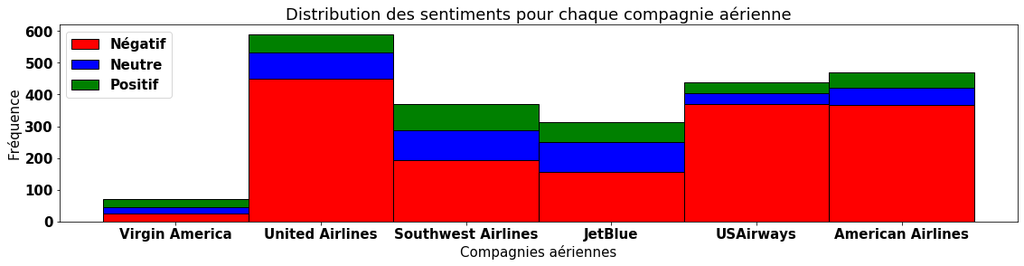

```python
# On compte les occurences des 0,1,2 pour chacune des compagnies dans notre dictionnaire
virgin_values, virgin_counts=np.unique((dict_sentiment['virginamerica']),return_counts=True)
united_values, united_counts=np.unique((dict_sentiment['united']),return_counts=True)
south_values, south_counts=np.unique((dict_sentiment['southwestair']),return_counts=True)
jetblue_values, jetblue_counts=np.unique((dict_sentiment['jetblue']),return_counts=True)
usairways_values, usairways_counts=np.unique((dict_sentiment['usairways']),return_counts=True)
american_values, american_counts=np.unique((dict_sentiment['americanair']),return_counts=True)

# Création d'un stacked barplot pour visualiser la distribution des sentiments des 6 compagnies dans la même figure
font = {'family' : 'normal',
        'weight' : 'bold',
        'size'   : 15}

matplotlib.rc('font', **font)

# Valeurs à visualiser
bars1 = [virgin_counts[0], united_counts[0], south_counts[0], jetblue_counts[0], usairways_counts[0], american_counts[0]]
bars2 = [virgin_counts[1], united_counts[1], south_counts[1], jetblue_counts[1], usairways_counts[1], american_counts[1]]
bars3 = [virgin_counts[2], united_counts[2], south_counts[2], jetblue_counts[2], usairways_counts[2], american_counts[2]]

# Hauteur des barres
bars = np.add(bars1, bars2).tolist()

# Postion sur l'axe des x pour chacune des barres
r = [0,1,2,3,4,5]

# Noms des labels
names = ['Virgin America','United Airlines','Southwest Airlines','JetBlue','USAirways','American Airlines']
barWidth = 1

# Création de la figure
plt.figure(figsize=(19,4))
plt.bar(r, bars1, color='r', edgecolor='black', width=barWidth)
plt.bar(r, bars2, bottom=bars1, color='b', edgecolor='black', width=barWidth)
plt.bar(r, bars3, bottom=bars, color='g', edgecolor='black', width=barWidth)
plt.legend(['Négatif','Neutre','Positif'])
plt.xticks(r, names, fontweight='bold')
plt.xlabel("Compagnies aériennes")
plt.ylabel('Fréquence')
plt.title('Distribution des sentiments pour chaque compagnie aérienne')


# Sauvegarde
#plt.savefig('combined_airlines')
# Affichage
plt.show()
```

**Description du diagramme**

Le diagramme comporte six bandes, soit une par compagnie aérienne à l'étude. La hauteur de chacune de ces bandes représente le nombre total de tweets mentionnant la compagnie aérienne. Chaque bande est composée de trois couleurs, soit le rouge, le bleu et le vert qui correspondent respectivement au nombre de tweets négatifs, neutres et positifs associés à la compagnie aérienne. Il est important de se rappeler que les étiquettes de sentiements ont été apposées à l'aide du classificateur 5 qui avait une précision d'environ 80% sur l'ensemble de validation. Ainsi, il y a une marge d'erreur à considérer dans lors de l'analyse de ce diagramme.

**Pertinence du diagramme**

Ce type de diagramme est très pertinent pour les équipes de stratégie, de relations publiques et de marketing d'une compagnie. En effet, ce diagramme, combiné avec une analyse des raisons principales expliquant le sentiment des usagers, peut permettre à la compagnie de concentrer ses efforts sur les enjeux urgents. Ainsi, une compagnie peut comprendre l'expérience de ces clients et agir rapidement pour résoudre leur problèmes et augmenter leur satisfaction. Le diagramme permet de "prendre le pouls" des clients d'une compagnie. Il est également très intéressant de faire l'exercice avec les tweets des compétiteurs pour mieux comprendre leur segment de marché.

Il serait très intéressant de répéter périodiquemment ce type d'analyse. Ainsi, ce diagramme pourrait même aider à percevoir l'impact réel de mesures correctives sur la satisfaction des clients.

De plus, il serait intéressant d'examiner les dates de publication des tweets pour savoir s'ils sont reliés à un évènement en particulier ou s'ils représentent réellement l'opinion en temps normal des clients face à la compagnie. Par exemple, rappelons-nous de la polémique entourant la passagère de *American Airlines* qui a été expulsée d'un vol alors qu'elle avait acheté un siège supplémentaire pour son violoncelle, tel qu'autorisé par les règlements fédéraux américains... (https://www.foxnews.com/travel/american-airlines-passenger-kicked-off-flight-after-buying-seat-for-her-30000-cello)

Finalement, il serait aussi intéressant de déterminer si la personne ayant écrit le tweet est réellement un client de l'entreprise ou s'il s'agit d'un individu quelconque.

## 2. Analyse de termes

Le POS-tagging (pour *part-of-speech tagging*, en français étiquetage grammatical) consiste à l'extraction de l'information grammaticale d'un token dans une phrase. Par exemple, la table ci-dessous donne un exemple du *POS-tagging* de la phrase *"The cat is white!"*

| The | cat | is | white | ! |
| --- | --- | --- | --- | --- |
| article | noun | verb | adjective | punctation |

Pour autant, le *POS-tagging* peut être plus complexe que les règles simples apprises à l'école. Il faut souvent des informations plus détaillées sur le rôle d'un terme dans une phrase. Pour notre problème, nous n'avons pas besoin d'utiliser un modèle linguistique plus complexe, nous allons utiliser ce qu'on appelle des *POS-tags* universelles.

En *POS-tagging*, chaque token est représenté par un tag. La liste des POS-tags utilisés sont disponibles ici : https://universaldependencies.org/u/pos/ .

```python
# NLTK POS-tagger

import nltk


#before using pos_tag function, you have to tokenize the sentence.
s = ['The', 'cat', 'is',  'white', '!']
taggs=nltk.pos_tag(s,tagset='universal')
print(taggs)
print(type(taggs))
print(taggs[0])
print(type(taggs[0]))
print(taggs[0][1])
print(type(taggs[0][1]))


# abbréviations utilisées par la libraire
#ADJ: adjective
#ADP: adposition
#ADV: adverb
#AUX: auxiliary
#CCONJ: coordinating conjunction
#DET: determiner
#INTJ: interjection
#NOUN: noun
#NUM: numeral
#PART: particle
#PRON: pronoun
#PROPN: proper noun
#PUNCT: punctuation
#SCONJ: subordinating conjunction
#SYM: symbol
#VERB: verb
#X: other
```

```
[('The', 'DET'), ('cat', 'NOUN'), ('is', 'VERB'), ('white', 'ADJ'), ('!', '.')]
<class 'list'>
('The', 'DET')
<class 'tuple'>
DET
<class 'str'>
```

##### Question 12. Implémentez un code qui collecte les 10 termes les plus fréquents pour chaque compagnie aérienne. (2 Pts)

Ici, vous n'allez considérer que les termes apparaissant dans les tweets positifs et négatifs.

De plus, nous allons utiliser la définition suivante de "terme":

1. Un mot qui est soit un adjectif, soit un nom
2. Un N-gram composé d'adjectifs suivit par un nom (par exemple, "nice place"), ou un nom suivi par un autre nom (par exemple, "sports club").

Ensuite, **générez une table** contenant les 10 termes les plus fréquents, avec leurs fréquences (en pourcentage) pour chaque compagnie.

*N'oubliez pas de supprimer le nom de la compagnie parmi les termes !*

```python
# On crée un classe qui trouve les mots les plus fréquents à travers des tweets
# On ignore les tweets dont le sentiment est ''neutre''
class AirLinesTopWordsFinder(object):

    def __init__(self):
        self.pipeline = PreprocessingPipeline(tokenization=True, twitterPreprocessing=False, stemming=False)

    def findTopTen(self, classifier, tweets):
        wordsPerCompany = {}
        words = []
        preprocessedTweets = []

        # We use the list of the most present tags that we found earlier
        acceptedNames = ['virginamerica', 'united', 'southwestair','jetblue', 'usairways', 'americanair']

        # get the airlines in the tweet
        airlinesPerTweet = detect_airline(tweets)

        for i in range(0, len(airlinesPerTweet)):
            if airlinesPerTweet[i] is not None:
                for airline in airlinesPerTweet[i]:
                    if airline not in acceptedNames:
                        airlinesPerTweet[i].remove(airline)

        # Preprocess the tweets and keep only adjectives, nouns and bigrams as specified
        for i in range(0, len(tweets)):
            preprocessedTweet = self.pipeline.preprocess(tweets[i])
            postTagTokens = nltk.pos_tag(preprocessedTweet,tagset='universal')

            adjectivesAndNouns = []

            for j in range(0, len(postTagTokens)):
                if postTagTokens[j][1] == "ADJ" or postTagTokens[j][1] == "NOUN":
                    adjectivesAndNouns.append(postTagTokens[j][0])
                    # Include bigramms composed of "ADJ" and "NOUN" or "NOUN" and "NOUN"
                    if j + 1 < len(postTagTokens):
                        if postTagTokens[j + 1][1] == "NOUN":
                            adjectivesAndNouns.append(postTagTokens[j][0] + " " + postTagTokens[j + 1][0])

            # fill the word vector with each token that passed the preprocessing and the post_tag
            for token in adjectivesAndNouns:
                token = token.lower()
                if token not in words:
                    words.append(token)

            preprocessedTweets.append(adjectivesAndNouns)

        # Create word vectors for each airline company
        for airlineVector in airlinesPerTweet:
            if airlineVector is None or len(airlineVector) == 0:
                continue

            for airline in airlineVector:
                #creates a dictionary key for each airline not yet encountered
                if airline not in wordsPerCompany.keys():
                    wordsPerCompany[airline] = []

                    for j in range(0, len(words)):
                        wordsPerCompany[airline].append(0)

        # Extract sentiment value for each tweet
        sentiment_vector = extract_sentiment(classifier, tweets)

        for i in range(0, len(tweets)):
            # if the sentiment is neutral, continue to the next iteration
            if sentiment_vector[i] == 1:
                continue

            # Iterate through the vector token matching the current tweet
            for token in preprocessedTweets[i]:
                bAirlineToken = False
                for airline in wordsPerCompany.keys():
                    lowerCaseToken = token.lower()
                    if airline in lowerCaseToken:
                        bAirlineToken = True
                        break

                # if the airline is contained in the token, skip this token
                if bAirlineToken is True:
                    continue

                if airlinesPerTweet[i] is not None and len(airlinesPerTweet[i]) != 0:
                    for airline in airlinesPerTweet[i]:
                        # add 1 to the value in the airline word count vector at the token index in the words vector
                        token = token.lower()
                        if token in words:
                            wordsPerCompany[airline][words.index(token)] += 1

        topTenWordsPerAirline = {}

        # for each word count vector in the airline dictionary, add a dictionary in the top ten dictionary with the
        # 20 max values, EXPLICATION FURTHER DOWN IN A MARKDOWN CELL!
        for airline in wordsPerCompany.keys():
            wordCounts = wordsPerCompany[airline]
            totalWords = sum(wordCounts)
            topTenWordsPerAirline[airline] = {}
            for i in range(0, 20):
                if len(wordCounts) <= 0:
                    break

                # finds the max number and its index in the word count vector
                maxNumber = max(wordCounts)

                if maxNumber == 0:
                    break

                maxNumberIndex = wordCounts.index(maxNumber)

                # adds these values to the top ten words dictionary, in the airlines dictionary
                topTenWordsPerAirline[airline][words[maxNumberIndex]] = (float(maxNumber) / float(totalWords)) * 100.00

                # replace the current maximum number with -1 to prevent it from being found again
                wordCounts[maxNumberIndex] = -1

        return topTenWordsPerAirline
```

```python
# Classe permettant de visualiser les résultats de la classe précédente.
class TableDisplayManager(object):

    def __init__(self):
        pass

    def generateTableForTopTen(self, topTenWordsPerAirline):

        rows = [["Word popularity"], ["1st"], ["2nd"], ["3rd"], ["4th"], ["5th"], ["6th"], ["7th"], ["8th"], ["9th"], ["10th"]]

        # We use the list of the most present tags that we found earlier and their corresponding company name
        names = { 'virginamerica' : 'Virgin America', 'united' : 'United Airline', 'southwestair' : 'Southwest Airlines', 'jetblue' : 'JetBlue', 'usairways' : 'USAirways', 'americanair' : 'American Airlines' }

        for airline in topTenWordsPerAirline.keys():

            if airline not in names.keys():
                continue

            rows[0].append(names[airline])

            orderedTopTenWordsPerAirline = []

            # order the key value pairs in a list
            for key, value in sorted(topTenWordsPerAirline[airline].items(), key=lambda item: item[1]):
                keyValuePair = []
                keyValuePair.append(key)
                keyValuePair.append(value)

                orderedTopTenWordsPerAirline.insert(0 , keyValuePair)

            # fill the appropriate row for each value
            for i in range(1, len(rows)):

                rowIndex = len(rows) - i

                if rowIndex > len(orderedTopTenWordsPerAirline):
                    rows[rowIndex].append(" ----- ")
                else:
                    keyValuePairIndex = len(orderedTopTenWordsPerAirline) - rowIndex;
                    keyValuePair = orderedTopTenWordsPerAirline[rowIndex - 1]
                    if keyValuePair[1] == 0:
                        rows[rowIndex].append(" ----- ")
                    else:
                        rows[rowIndex].append("'" + keyValuePair[0] + "' : " + "{:10.2f}".format(keyValuePair[1]) + " %")

        fig, axs =plt.subplots(2,1)
        axs[0].axis('tight')
        axs[0].axis('off')
        axs[1].axis('off')
        table = axs[0].table(cellText=rows,loc='center')
        table.auto_set_font_size(False)
        table.set_fontsize(12)
        table.scale(5,3)

        plt.show()
```

```python
topTenFinder = AirLinesTopWordsFinder()
topTenWordsPerAirline = topTenFinder.findTopTen(classifier, train_X)
```

**Explications**

Nous présentons 2 tables différentes.

La première table contient les 10 termes les plus fréquents (incluant de potentiels bigrams) naïvement extraits de la classe AirlinesTopWordsFinder. Par contre, le *POS-tagger* de *NLTK* détecte parfois des signes de ponctuation comme étant un nom (dans *NOUN*), ce qui produit des résultats parfois étranges. De plus, des surnoms ou accronymes des compagnies aériennes apparaissent parfois dans les termes les plus fréquents, par exemple *aa* dans les tweets de *American Airlines*.

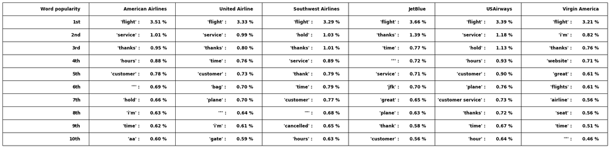

```
Voici la table avec naivement les 10 premiers termes
```

```python
# On extrait les 10 termes avec la plus haute fréquence (parmis les 20 sortie par la classe)
ten_dict={}
compagnies=['americanair','united','southwestair','jetblue', 'usairways','virginamerica']


for company in compagnies:
    only_10={k: topTenWordsPerAirline[company][k] for k in list(topTenWordsPerAirline[company])[:10]}
    ten_dict[company]=only_10



displayManager = TableDisplayManager()
displayManager.generateTableForTopTen(ten_dict)
print('Voici la table avec naivement les 10 premiers termes')
```

```python
# Manuellement, on retire les mots qui n'ont pas de sens dans la table naïve.
# Il y a des limites aux capacités de l'automatisation
del topTenWordsPerAirline['americanair']['"']
del topTenWordsPerAirline['americanair']["i'm"]
del topTenWordsPerAirline['americanair']['aa']
del topTenWordsPerAirline['united']['"']
del topTenWordsPerAirline['united']["i'm"]
del topTenWordsPerAirline['southwestair']['"']
del topTenWordsPerAirline['jetblue']['"']
del topTenWordsPerAirline['virginamerica']["i'm"]
del topTenWordsPerAirline['virginamerica']['"']
```

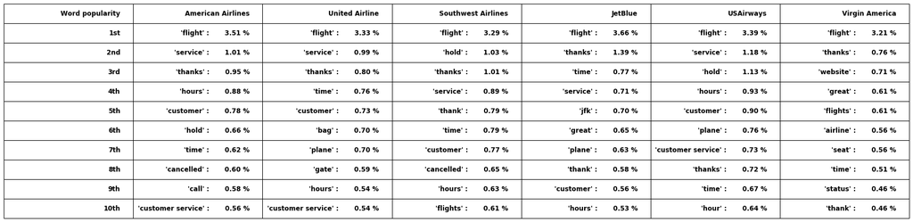

```
Voici la table où les surnoms des compagnies(e.g. aa pour American Airlines) et les signes de ponctuation faussement catégorisés comme étant des NOUN ont été retirés
```

```python
ten_dict={}
compagnies=['americanair','united','southwestair','jetblue', 'usairways','virginamerica']


for company in compagnies:
    only_10={k: topTenWordsPerAirline[company][k] for k in list(topTenWordsPerAirline[company])[:10]}
    ten_dict[company]=only_10



displayManager = TableDisplayManager()
displayManager.generateTableForTopTen(ten_dict)




print('Voici la table où les surnoms des compagnies(e.g. aa pour American Airlines) et les signes de ponctuation faussement catégorisés comme étant des NOUN ont été retirés')
```

##### Question 13. Que conclure de la table généré à la question 12 pour les compagnies ? (1 Pt)

**Réponse**

Pour facilité l'interprétation de ces résultats, il serait intéressant de refaire l'analyse, mais en faisant un tableau des termes les plus fréquents simplement pour les tweets positifs et un autre pour les tweets négatifs. Ainsi, il serait possible de *comprendre* un tant soit peu les raisons derrière les sentiments des usagers. Cela serait très pertienent dans le contexte de la construction d'un plan stratégique pour les entreprises. L'apparition du bigrams *customer service* dans l'un ou l'autre de ces deux tableaux aurait une signification complètement différente.

On observe également que peu de bigrams figurent parmi le top 10 des termes les plus fréquents, ce qui est logique, car il est beaucoup moins probable qu'une combinaison de deux mots soit répétée. En fait, le seul bigram ayant une féquence assez élevée pour faire partie des top 10 est *customer service*, ce qui n'est pas surprenant.

# III/ Bonus (2 points)

Les noms de personnes, les noms de sociétés et les emplacements sont appelés "entités nommées". La reconnaissance d'entité nommée (NER, pour *Named-entity recognition*) consiste à extraire les entités nommées en les classant à l'aide de catégories prédéfinies. Dans cette section bonus, vous utiliserez un outil de NER pour extraire automatiquement des entités nommées des tweets. Cette approche est suffisamment générique pour récupérer des informations sur d’autres sociétés ou même des noms de produits et de personnes.

**Pour le bonus, vous êtes libres d'utiliser n'importe quel NER implémenté en Python.**

##### Question Bonus 1. Implémentez un code qui génère une table contenant le top 10 des NER de la base de données. (1 point)

Cette table doit contenir les fréquences des entités nommées. Ensuite, générez un diagramme en bar qui montre le nombre de tweets positifs, négatifs ou neutres pour chacunes des 10 NER. Décrivez le résultat obtenu.

##### Question Bonus 2. Générez une table similaire à la question 12 pour le top 10 des NER pour chaque compagnie. (1 point)

Que peut-on conclure de ces résultats?